# Chapter 9 Diagnostics for Leverage and Influence

Tianhai Zu (zuti@mail.uc.edu)

**Acknowledgment**: the materials below are partially based on Montgomery, D. C., Peck, E. A., Vining, G. G., Introduction to Linear Regression Analysis (5th Edition), Wiley Series in Probability and Statistics, 2012. This materials was initilated by Yichen Qin and modified by Tianhai Zu for teaching purpose.

### High Leverage Point

A high leverage point is:

- unusual x-value
- very little effect on regression coefficients.

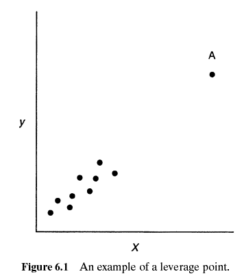

- unusual in x (i.e., large) and unusual in y (i.e., large residual);

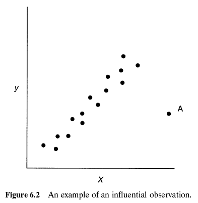

### Leverage

Leverage is a measure of how far away an observation is from those of the other observations.

The average size of the leverage is $(k+1)/n$.

Traditionally, any $h_{ii} > 2(k+1)/n$ indicates a leverage point.

Appropriate for large $n$; otherwise consider large as compared to other values

An observation with large $h_{ii}$ and a large residual is likely to be influential

### Treatment of Outliers

Discard if there is an error in recording a measured value.

Do not discard if it is a valid observation, and apply robust estimation techniques.

- These techniques offer an alternative to deleting an influential observation
- Observations are retained but down-weighted in proportion to residual magnitude or influence.

### Measures of Influence

The influence measures discussed here are those that measure the effect of deleting the ith observation.

- **Cook’s Distance**, which measures the effect on coefficient estimation.
- DFBETAS, which measures the effect on coefficient estimation (optional).
- DFFITS, which measures the effect on fitted values (optional).

### Cook’s Distance

$$D_i=\frac{ e_i^2 }{(k+1) MSRes} \frac{h_{ii}}{(1-h_{ii})^2} = \frac{ e_{(i)}^2 h_{ii} }{(k+1) MSRes}$$

What contributes to $D_i$:

- How well the model fits the ith observation, that is, residual $e_i$.
- How far that point is from the remaining dataset, that is, leverage $h_ii$.

Large values of $D_i$ indicate an influential point, usually if $D_i > 1$.

### Example

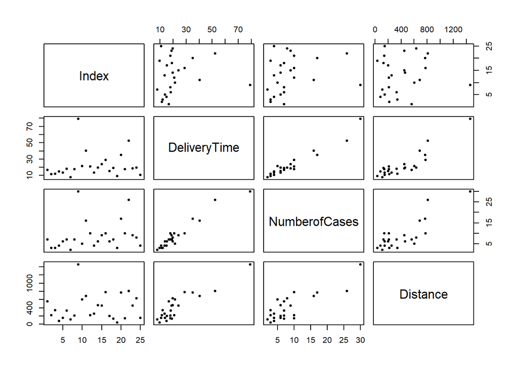

```r
delivery <- read.csv("data_delivery.csv",h=T)
pairs (delivery,pch=20)
```

```r
model1 <- lm(DeliveryTime ~ NumberofCases + Distance, data=delivery)
influence.measures(model1)
```

```
## Influence measures of
##   lm(formula = DeliveryTime ~ NumberofCases + Distance, data = delivery) :
##
##      dfb.1_ dfb.NmbC dfb.Dstn   dffit cov.r   cook.d    hat inf
## 1  -0.18727  0.41131 -0.43486 -0.5709 0.871 1.00e-01 0.1018
## 2   0.08979 -0.04776  0.01441  0.0986 1.215 3.38e-03 0.0707
## 3  -0.00352  0.00395 -0.00285 -0.0052 1.276 9.46e-06 0.0987
## 4   0.45196  0.08828 -0.27337  0.5008 0.876 7.76e-02 0.0854
## 5  -0.03167 -0.01330  0.02424 -0.0395 1.240 5.43e-04 0.0750
## 6  -0.01468  0.00179  0.00108 -0.0188 1.200 1.23e-04 0.0429
## 7   0.07807 -0.02228 -0.01102  0.0790 1.240 2.17e-03 0.0818
## 8   0.07120  0.03338 -0.05382  0.0938 1.206 3.05e-03 0.0637
## 9  -2.57574  0.92874  1.50755  4.2961 0.342 3.42e+00 0.4983   *
## 10  0.10792 -0.33816  0.34133  0.3987 1.305 5.38e-02 0.1963
## 11 -0.03427  0.09253 -0.00269  0.2180 1.172 1.62e-02 0.0861
## 12 -0.03027 -0.04867  0.05397 -0.0677 1.291 1.60e-03 0.1137
## 13  0.07237 -0.03562  0.01134  0.0813 1.207 2.29e-03 0.0611
## 14  0.04952 -0.06709  0.06182  0.0974 1.228 3.29e-03 0.0782
## 15  0.02228 -0.00479  0.00684  0.0426 1.192 6.32e-04 0.0411
## 16 -0.00269  0.06442 -0.08419 -0.0972 1.369 3.29e-03 0.1659
## 17  0.02886  0.00649 -0.01570  0.0339 1.219 4.01e-04 0.0594
## 18  0.24856  0.18973 -0.27243  0.3653 1.069 4.40e-02 0.0963
## 19  0.17256  0.02357 -0.09897  0.1862 1.215 1.19e-02 0.0964
## 20  0.16804 -0.21500 -0.09292 -0.6718 0.760 1.32e-01 0.1017
## 21 -0.16193 -0.29718  0.33641 -0.3885 1.238 5.09e-02 0.1653
## 22  0.39857 -1.02541  0.57314 -1.1950 1.398 4.51e-01 0.3916   *
## 23 -0.15985  0.03729 -0.05265 -0.3075 0.890 2.99e-02 0.0413
## 24 -0.11972  0.40462 -0.46545 -0.5711 0.948 1.02e-01 0.1206
## 25 -0.01682  0.00085  0.00559 -0.0176 1.231 1.08e-04 0.0666
```

```r
cooks.distance(model1)
```

```
##            1            2            3            4            5
## 1.000921e-01 3.375704e-03 9.455785e-06 7.764718e-02 5.432217e-04
##            6            7            8            9           10
## 1.231067e-04 2.171604e-03 3.051135e-03 3.419318e+00 5.384516e-02
##           11           12           13           14           15
## 1.619975e-02 1.596392e-03 2.294737e-03 3.292786e-03 6.319880e-04
##           16           17           18           19           20
## 3.289086e-03 4.013419e-04 4.397807e-02 1.191868e-02 1.324449e-01
##           21           22           23           24           25
## 5.086063e-02 4.510455e-01 2.989892e-02 1.023224e-01 1.084694e-04
```

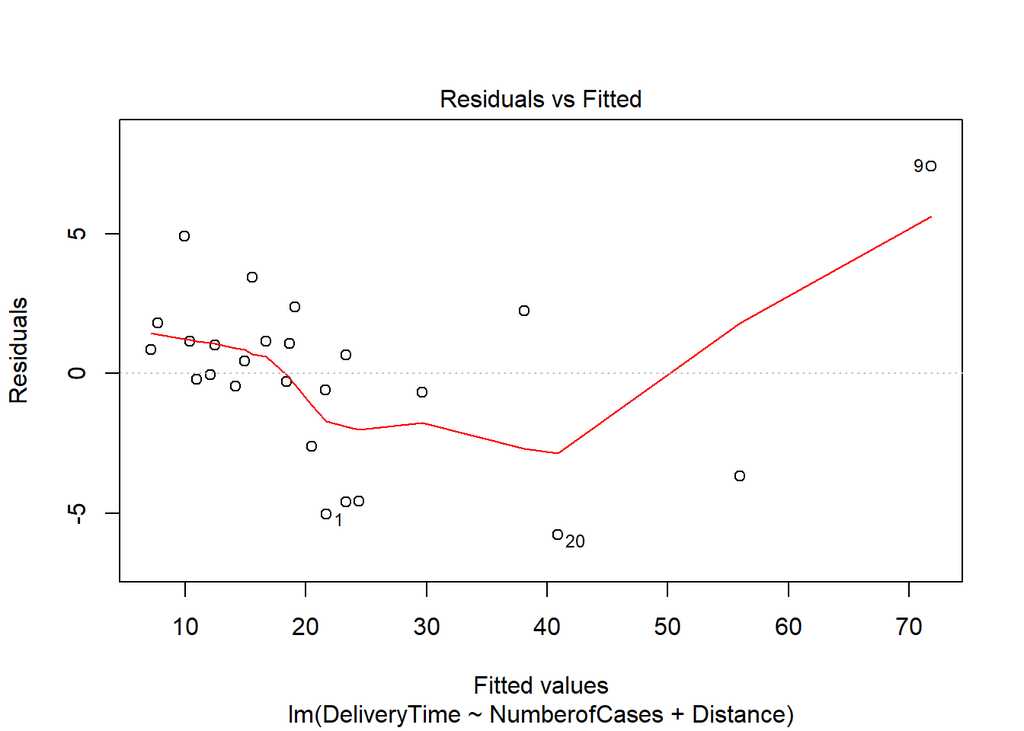

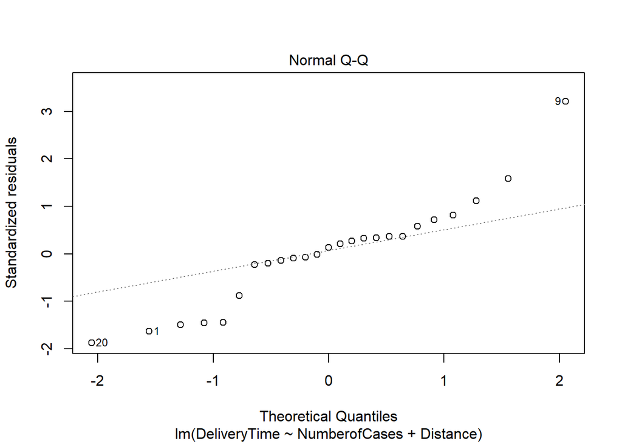

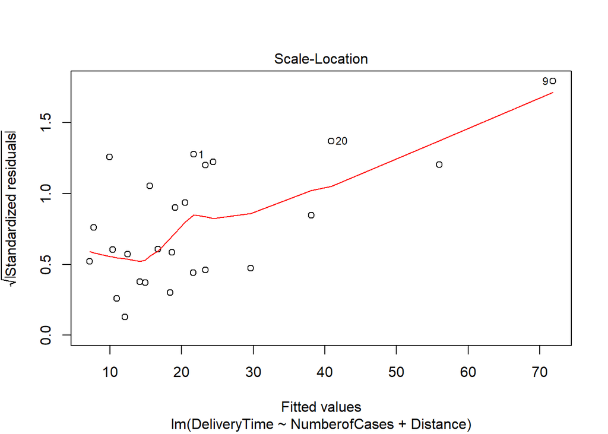

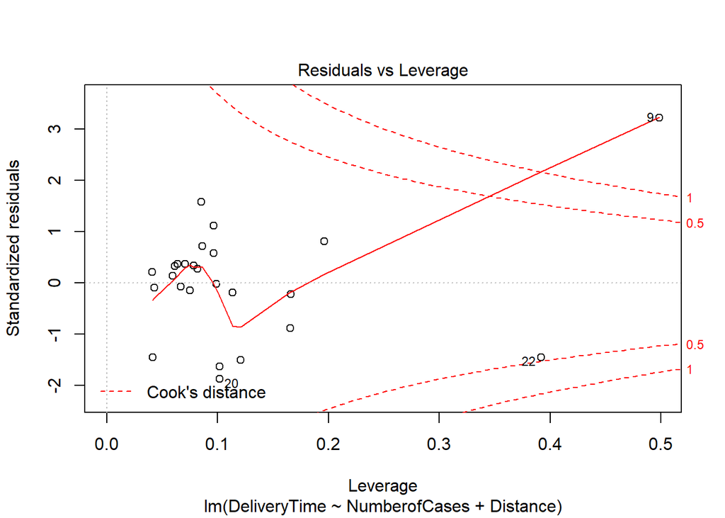

```r
plot(model1)
```